# Introduction

**Analyzing Passenger Satisfaction in Airline Services: An Exploratory Data Analysis Approach**

**Introduction:** Understanding customer satisfaction is a critical factor in the airline industry, as it directly impacts brand loyalty, reputation, and revenue. This project performs an in-depth exploratory data analysis (EDA) on a commercial airline passenger dataset to uncover the key factors that influence satisfaction levels.

The dataset contains both categorical and numerical features, including service quality metrics (e.g., seat comfort, online boarding), travel details (e.g., flight class, travel type), and delays. Through visualizations and statistical insights, we explore how these variables interact with the satisfaction label, identify trends, assess feature importance, and detect data imbalances or anomalies.

This analysis serves as a foundation for building predictive models and making data-driven recommendations for improving customer experience in the airline industry.

# Importing Libraries and Dataset

```python
# Import necessary libraries
import pandas as pd
import matplotlib.pyplot as plt
import seaborn as sns
from sklearn.model_selection import train_test_split
from sklearn.preprocessing import LabelEncoder, StandardScaler
from sklearn.impute import SimpleImputer
from sklearn.ensemble import RandomForestClassifier, AdaBoostClassifier
from sklearn.metrics import classification_report, accuracy_score, f1_score, confusion_matrix
from sklearn.model_selection import GridSearchCV, cross_val_score
from sklearn.tree import DecisionTreeClassifier
from sklearn.linear_model import LogisticRegression

import warnings
warnings.filterwarnings("ignore")
```

```python
# Load datasets
train_data = pd.read_csv('train.csv')
test_data = pd.read_csv('test.csv')

# Drop irrelevant columns
columns_to_drop = ['Unnamed: 0', 'id']
train_data = train_data.drop(columns=columns_to_drop, axis=1)
test_data = test_data.drop(columns=columns_to_drop, axis=1)

print(train_data.shape)
train_data.head()
```

```
(103904, 23)
```

|  | Gender | Customer Type | Age | Type of Travel | Class | Flight Distance | Inflight wifi service | Departure/Arrival time convenient | Ease of Online booking | Gate location | ... | Inflight entertainment | On-board service | Leg room service | Baggage handling | Checkin service | Inflight service | Cleanliness | Departure Delay in Minutes | Arrival Delay in Minutes | satisfaction |
| --- | --- | --- | --- | --- | --- | --- | --- | --- | --- | --- | --- | --- | --- | --- | --- | --- | --- | --- | --- | --- | --- |
| 0 | Male | Loyal Customer | 13 | Personal Travel | Eco Plus | 460 | 3 | 4 | 3 | 1 | ... | 5 | 4 | 3 | 4 | 4 | 5 | 5 | 25 | 18.0 | neutral or dissatisfied |
| 1 | Male | disloyal Customer | 25 | Business travel | Business | 235 | 3 | 2 | 3 | 3 | ... | 1 | 1 | 5 | 3 | 1 | 4 | 1 | 1 | 6.0 | neutral or dissatisfied |
| 2 | Female | Loyal Customer | 26 | Business travel | Business | 1142 | 2 | 2 | 2 | 2 | ... | 5 | 4 | 3 | 4 | 4 | 4 | 5 | 0 | 0.0 | satisfied |
| 3 | Female | Loyal Customer | 25 | Business travel | Business | 562 | 2 | 5 | 5 | 5 | ... | 2 | 2 | 5 | 3 | 1 | 4 | 2 | 11 | 9.0 | neutral or dissatisfied |
| 4 | Male | Loyal Customer | 61 | Business travel | Business | 214 | 3 | 3 | 3 | 3 | ... | 3 | 3 | 4 | 4 | 3 | 3 | 3 | 0 | 0.0 | satisfied |

5 rows × 23 columns

```python
train_data.shape
test_data.head()
```

|  | Gender | Customer Type | Age | Type of Travel | Class | Flight Distance | Inflight wifi service | Departure/Arrival time convenient | Ease of Online booking | Gate location | ... | Inflight entertainment | On-board service | Leg room service | Baggage handling | Checkin service | Inflight service | Cleanliness | Departure Delay in Minutes | Arrival Delay in Minutes | satisfaction |
| --- | --- | --- | --- | --- | --- | --- | --- | --- | --- | --- | --- | --- | --- | --- | --- | --- | --- | --- | --- | --- | --- |
| 0 | Female | Loyal Customer | 52 | Business travel | Eco | 160 | 5 | 4 | 3 | 4 | ... | 5 | 5 | 5 | 5 | 2 | 5 | 5 | 50 | 44.0 | satisfied |
| 1 | Female | Loyal Customer | 36 | Business travel | Business | 2863 | 1 | 1 | 3 | 1 | ... | 4 | 4 | 4 | 4 | 3 | 4 | 5 | 0 | 0.0 | satisfied |
| 2 | Male | disloyal Customer | 20 | Business travel | Eco | 192 | 2 | 0 | 2 | 4 | ... | 2 | 4 | 1 | 3 | 2 | 2 | 2 | 0 | 0.0 | neutral or dissatisfied |
| 3 | Male | Loyal Customer | 44 | Business travel | Business | 3377 | 0 | 0 | 0 | 2 | ... | 1 | 1 | 1 | 1 | 3 | 1 | 4 | 0 | 6.0 | satisfied |
| 4 | Female | Loyal Customer | 49 | Business travel | Eco | 1182 | 2 | 3 | 4 | 3 | ... | 2 | 2 | 2 | 2 | 4 | 2 | 4 | 0 | 20.0 | satisfied |

5 rows × 23 columns

```python
train_data.info()
```

```
<class 'pandas.core.frame.DataFrame'>
RangeIndex: 103904 entries, 0 to 103903
Data columns (total 23 columns):
 #   Column                             Non-Null Count   Dtype
---  ------                             --------------   -----
 0   Gender                             103904 non-null  object
 1   Customer Type                      103904 non-null  object
 2   Age                                103904 non-null  int64
 3   Type of Travel                     103904 non-null  object
 4   Class                              103904 non-null  object
 5   Flight Distance                    103904 non-null  int64
 6   Inflight wifi service              103904 non-null  int64
 7   Departure/Arrival time convenient  103904 non-null  int64
 8   Ease of Online booking             103904 non-null  int64
 9   Gate location                      103904 non-null  int64
 10  Food and drink                     103904 non-null  int64
 11  Online boarding                    103904 non-null  int64
 12  Seat comfort                       103904 non-null  int64
 13  Inflight entertainment             103904 non-null  int64
 14  On-board service                   103904 non-null  int64
 15  Leg room service                   103904 non-null  int64
 16  Baggage handling                   103904 non-null  int64
 17  Checkin service                    103904 non-null  int64
 18  Inflight service                   103904 non-null  int64
 19  Cleanliness                        103904 non-null  int64
 20  Departure Delay in Minutes         103904 non-null  int64
 21  Arrival Delay in Minutes           103594 non-null  float64
 22  satisfaction                       103904 non-null  object
dtypes: float64(1), int64(17), object(5)
memory usage: 18.2+ MB
```

# Data cleaning

## Remove duplicates

```python
print("TRAIN DATA")
print("Before removing duplicates, data shape:", train_data.shape)

# Counting duplicate rows
duplicate_rows = train_data.duplicated()
print(f"Number of duplicate rows: {duplicate_rows.sum()}")

#data.drop_duplicates(subset='id', keep='first', inplace=True)
train_data.drop_duplicates(keep='first', inplace=True)
print("After removing duplicates, data shape:", train_data.shape)
```

[output not shown]

```python
print("TEST DATA")
print("Before removing duplicates, data shape:", test_data.shape)

# Counting duplicate rows
duplicate_rows = test_data.duplicated()
print(f"Number of duplicate rows: {duplicate_rows.sum()}")

#data.drop_duplicates(subset='id', keep='first', inplace=True)
test_data.drop_duplicates(keep='first', inplace=True)
print("After removing duplicates, data shape:", test_data.shape)
```

```
TEST DATA
Before removing duplicates, data shape: (25976, 23)
Number of duplicate rows: 0
After removing duplicates, data shape: (25976, 23)
```

## Handling missing values

```python
# Check for missing values
missing_values = train_data.isnull().sum()
print("\nMissing Values in Train Data:")
print(missing_values)
```

```
Missing Values in Train Data:
Gender                                 0
Customer Type                          0
Age                                    0
Type of Travel                         0
Class                                  0
Flight Distance                        0
Inflight wifi service                  0
Departure/Arrival time convenient      0
Ease of Online booking                 0
Gate location                          0
Food and drink                         0
Online boarding                        0
Seat comfort                           0
Inflight entertainment                 0
On-board service                       0
Leg room service                       0
Baggage handling                       0
Checkin service                        0
Inflight service                       0
Cleanliness                            0
Departure Delay in Minutes             0
Arrival Delay in Minutes             310
satisfaction                           0
dtype: int64
```

```python
# Check for missing values
missing_values = test_data.isnull().sum()
print("\nMissing Values in Test Data:")
print(missing_values)
```

```
Missing Values in Test Data:
Gender                                0
Customer Type                         0
Age                                   0
Type of Travel                        0
Class                                 0
Flight Distance                       0
Inflight wifi service                 0
Departure/Arrival time convenient     0
Ease of Online booking                0
Gate location                         0
Food and drink                        0
Online boarding                       0
Seat comfort                          0
Inflight entertainment                0
On-board service                      0
Leg room service                      0
Baggage handling                      0
Checkin service                       0
Inflight service                      0
Cleanliness                           0
Departure Delay in Minutes            0
Arrival Delay in Minutes             83
satisfaction                          0
dtype: int64
```

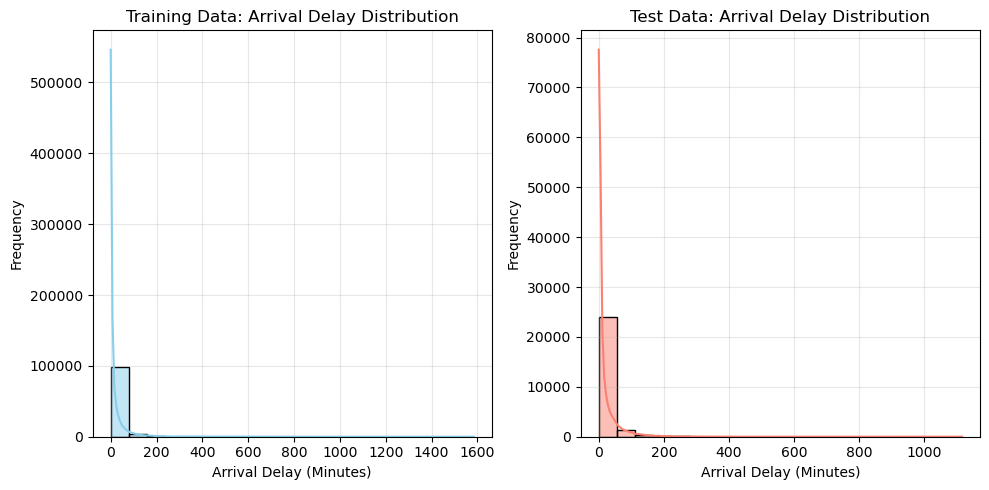

```python
plt.figure(figsize=(10, 5))

# Train_data histogram
plt.subplot(1, 2, 1)
sns.histplot(train_data['Arrival Delay in Minutes'], bins=20, color='skyblue', kde=True)
plt.title('Training Data: Arrival Delay Distribution')
plt.xlabel('Arrival Delay (Minutes)')
plt.ylabel('Frequency')
plt.grid(True, alpha=0.3)

# Test_data histogram
plt.subplot(1, 2, 2)
sns.histplot(test_data['Arrival Delay in Minutes'], bins=20, color='salmon', kde=True)
plt.title('Test Data: Arrival Delay Distribution')
plt.xlabel('Arrival Delay (Minutes)')
plt.ylabel('Frequency')
plt.grid(True, alpha=0.3)

plt.tight_layout()
plt.show()
```

```python
# Median imputation for missing values (skewed data for both train & test sets)
num_imputer = SimpleImputer(strategy='median')

numerical_cols = train_data.select_dtypes(include=['float64', 'int64']).columns
categorical_cols = train_data.select_dtypes(include=['object']).columns

train_data[numerical_cols] = num_imputer.fit_transform(train_data[numerical_cols])

test_data[numerical_cols] = num_imputer.transform(test_data[numerical_cols])
```

# EDA

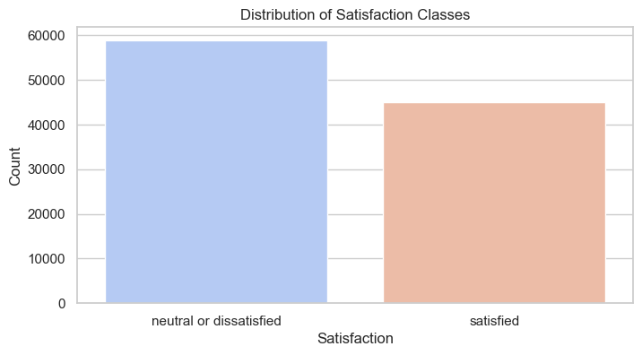

```python
# Distribution of the target variable
plt.figure(figsize=(8, 4))
sns.countplot(data=train_data, x='satisfaction', palette='coolwarm')
plt.title("Distribution of Satisfaction Classes")
plt.xlabel("Satisfaction")
plt.ylabel("Count")
plt.show()
```

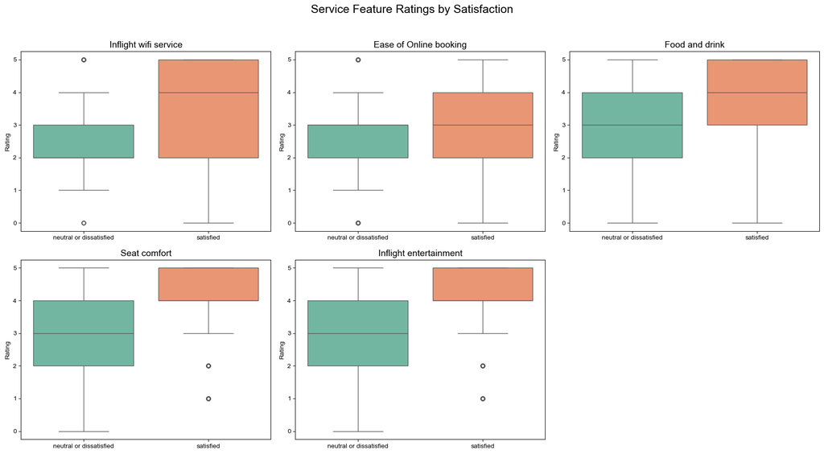

```python
# Create boxplots of service features grouped by satisfaction
fig, axes = plt.subplots(nrows=2, ncols=3, figsize=(18, 10))
fig.suptitle("Service Feature Ratings by Satisfaction", fontsize=18)

# Set style
sns.set(style="whitegrid")

# Selected service features
selected_service_features = [
    "Inflight wifi service",
    "Ease of Online booking",
    "Food and drink",
    "Seat comfort",
    "Inflight entertainment"
]

for i, ax in enumerate(axes.flatten()):
    if i < len(selected_service_features):
        feature = selected_service_features[i]
        sns.boxplot(data=train_data, x="satisfaction", y=feature, palette="Set2", ax=ax)
        ax.set_title(feature, fontsize=14)
        ax.set_xlabel("")
        ax.set_ylabel("Rating")
    else:
        ax.axis("off")

plt.tight_layout(rect=[0, 0, 1, 0.96])
plt.show()
```

1. Median Differences:

If the median line (horizontal line in the box) for the “satisfied” group is consistently higher, it suggests that higher ratings in that feature are associated with satisfaction.

2. Distribution Spread:

Wider boxes indicate more variability in how customers rate that feature. If dissatisfied customers have a wider box and lower medians, that feature may need improvement.

3. Outliers:

Outliers (dots outside whiskers) can show individual unusual experiences — e.g., some satisfied customers may still rate a service poorly, suggesting tolerance or variability in expectations.

4. Feature Importance (Visually):

If a feature shows a large gap in median rating between satisfied and dissatisfied groups (e.g., "Inflight entertainment"), it could be a key driver of satisfaction. Features with similar distributions across both groups may be less influential.

# Preprocessing

```python
# Encode categorical variables
label_encoders = {}
for col in categorical_cols:
    le = LabelEncoder()
    train_data[col] = le.fit_transform(train_data[col])
    test_data[col] = le.transform(test_data[col])
    label_encoders[col] = le

# Separate features and target variable
X_train = train_data.drop('satisfaction', axis=1)
y_train = train_data['satisfaction']
X_test = test_data.drop('satisfaction', axis=1)
y_test = test_data['satisfaction']

# Scale numerical features
scaler = StandardScaler()
X_train[numerical_cols] = scaler.fit_transform(X_train[numerical_cols])
X_test[numerical_cols] = scaler.transform(X_test[numerical_cols])
```

```python
y_train.head() # 0 for neutral or dissatisfied | 1 for satisfied
```

```
0    0
1    0
2    1
3    0
4    1
Name: satisfaction, dtype: int32
```

# Classification Models' Training & Hyperparameter Tunning

## Logistic Regression

```python
# Logistic Regression
logreg = LogisticRegression(random_state=42)

# Define the parameter grid
param_grid = {
    'penalty': ['l1', 'l2'],                    # Regularization type
    'C': [0.1, 1, 10],                          # Inverse of regularization strength
    'solver': ['lbfgs', 'liblinear', 'sag'],    # Optimization algorithm
    'max_iter': [100, 200, 500],                # Maximum iterations
    #'class_weight': [None, 'balanced'],        # Handle class imbalance (not needed, no severe class imbalance)
}

# GridSearchCV with 5-fold cross-validation
grid_search_logreg = GridSearchCV(
    estimator=logreg,
    param_grid=param_grid,
    cv=5,
    n_jobs=-1,
    verbose=2,                  # Print progress (computation time & score)
    scoring='accuracy'
)

# Model training
grid_search_logreg.fit(X_train, y_train)

# Best hyperparameters and best model
best_logreg_params = grid_search_logreg.best_params_
best_logreg = grid_search_logreg.best_estimator_

print("Best Parameters:", best_logreg_params)
```

```
Fitting 5 folds for each of 54 candidates, totalling 270 fits
Best Parameters: {'C': 1, 'max_iter': 100, 'penalty': 'l2', 'solver': 'sag'}
```

```python
# Cross-validation results for best Logistic Regression model
cv_scores = cross_val_score(best_logreg, X_train, y_train, cv=5, scoring='accuracy')
print("\nCross-validation scores:", cv_scores)
print("Mean CV Accuracy:", cv_scores.mean())
```

```
Cross-validation scores: [0.87599249 0.87339397 0.87373081 0.87512632 0.880077  ]
Mean CV Accuracy: 0.8756641170010789
```

## Random Forest

```python
# Random Forest Classifier
rf = RandomForestClassifier(random_state=42)

# For hyperparameter tunning
param_grid = {
    'n_estimators': [25, 50, 100],          # Number of trees used
    'max_depth': [10, 20, 30],              # Maximum depth of trees
    'min_samples_split': [2, 5, 10],        # Minimum samples required to split a node
    'min_samples_leaf': [1, 2, 4],          # Minimum samples required at a leaf node
}

# GridSearchCV with 5-fold cross-validation
grid_search_rf = GridSearchCV(
    estimator=rf,
    param_grid=param_grid,
    cv=5,
    n_jobs=-1,
    verbose=2,                     # Print progress (computation time & score)
    scoring='accuracy'
)

# Model training
grid_search_rf.fit(X_train, y_train)

# Best hyperparameters and best model
best_params = grid_search_rf.best_params_
best_rf = grid_search_rf.best_estimator_

print("Best Parameters:", best_params)
```

```
Fitting 5 folds for each of 81 candidates, totalling 405 fits
Best Parameters: {'max_depth': 30, 'min_samples_leaf': 1, 'min_samples_split': 10, 'n_estimators': 100}
```

```python
# Cross-validation results for best Random Forest model
cv_scores_rf = cross_val_score(best_rf, X_train, y_train, cv=5, scoring='accuracy')
print("\nCross-validation scores:", cv_scores_rf)
print("Mean CV Accuracy:", cv_scores_rf.mean())
```

```
Cross-validation scores: [0.96179202 0.96188826 0.96044464 0.96347625 0.96414822]
Mean CV Accuracy: 0.962349878718247
```

## Adaboost

```python
# Base decision tree estimator that will be used in Adaboost
base_estimator = DecisionTreeClassifier(random_state=42)

# AdaBoost Classifier
ada = AdaBoostClassifier(
    estimator=base_estimator,
    random_state=42
)

# For hyperparameter tunning
param_grid = {
    'n_estimators': [25, 50, 100],          # Number of weak learners
    'learning_rate': [0.01, 0.1, 1.0],      # Shrinks the contribution of each classifier
    'algorithm': ['SAMME', 'SAMME.R'],      # AdaBoost algorithm type
    'estimator__max_depth': [1, 2, 3]       # Depth of weak learners
}
# GridSearchCV with 5-fold cross-validation
grid_search_ada = GridSearchCV(
    estimator=ada,
    param_grid=param_grid,
    cv=5,
    n_jobs=-1,
    verbose=2,                     # Print progress (computation time & score)
    scoring='accuracy'
)

# Model training
grid_search_ada.fit(X_train, y_train)

# Best hyperparameters and best model
best_params = grid_search_ada.best_params_
best_ada = grid_search_ada.best_estimator_

print("Best Parameters:", best_params)
```

```
Fitting 5 folds for each of 54 candidates, totalling 270 fits
```

```
Best Parameters: {'algorithm': 'SAMME.R', 'estimator__max_depth': 3, 'learning_rate': 1.0, 'n_estimators': 100}
```

```python
# Cross-validation results for best Adaboost model
cv_scores_ada = cross_val_score(best_ada, X_train, y_train, cv=5, scoring='accuracy')
print("\nCross-validation scores:", cv_scores_ada)
print("Mean CV Accuracy:", cv_scores_ada.mean())
```

```
Cross-validation scores: [0.95361147 0.95774987 0.95491074 0.95515134 0.95736285]
Mean CV Accuracy: 0.9557572529026409
```

# Models Evaluation

## Model's Performance Evaluation Over Test Set

```python
logreg_pred = best_logreg.predict(X_test)

# Evaluate Logistic Regression
logreg_accuracy = accuracy_score(y_test, logreg_pred)
logreg_cm = confusion_matrix(y_test, logreg_pred)
logreg_report = classification_report(y_test, logreg_pred)

print("Logistic Regression Model Accuracy:", logreg_accuracy)
print("\nLogistic Regression Confusion Matrix:\n", logreg_cm)
print("\nLogistic Regression Classification Report:\n", logreg_report)
```

```
Logistic Regression Model Accuracy: 0.8709963042808746

Logistic Regression Confusion Matrix:
 [[13128  1445]
 [ 1906  9497]]

Logistic Regression Classification Report:
               precision    recall  f1-score   support

           0       0.87      0.90      0.89     14573
           1       0.87      0.83      0.85     11403

    accuracy                           0.87     25976
   macro avg       0.87      0.87      0.87     25976
weighted avg       0.87      0.87      0.87     25976
```

**Logistic Regression Model**

- The model correctly classifies 87% of all cases (accuracy).
- There is a balance between Precision & Recall (around 87%), meaning that there is no bias towards either class.
- The weighted average F1-score matches the accuracy, which means that there are no severe class imbalance issues.

```python
rf_pred = best_rf.predict(X_test)

# Evaluate Random Forest
rf_accuracy = accuracy_score(y_test, rf_pred)
rf_cm = confusion_matrix(y_test, rf_pred)
rf_report = classification_report(y_test, rf_pred)

print("Random Forest Model Accuracy:", rf_accuracy)
print("\nRandom Forest Confusion Matrix:\n", rf_cm)
print("\nRandom Forest Classification Report:\n", rf_report)
```

```
Random Forest Model Accuracy: 0.962272867262088

Random Forest Confusion Matrix:
 [[14255   318]
 [  662 10741]]

Random Forest Classification Report:
               precision    recall  f1-score   support

           0       0.96      0.98      0.97     14573
           1       0.97      0.94      0.96     11403

    accuracy                           0.96     25976
   macro avg       0.96      0.96      0.96     25976
weighted avg       0.96      0.96      0.96     25976
```

**Random Forest Model**

- The accuracy (96.2%) and F1-score (0.96) are significantly better than Logistic Regression (87%).
- There is also a great improvement in Recall for satisfied Customers. This model identifies almost all satisfied customers (just 6% missed).
- Unlike Logistic Regression, this model automatically selects important features, which can be one reason for its better performance.

```python
ada_pred = best_ada.predict(X_test)

# Evaluate AdaBoost
ada_accuracy = accuracy_score(y_test, ada_pred)
ada_cm = confusion_matrix(y_test, ada_pred)
ada_report = classification_report(y_test, ada_pred)

print("AdaBoost Model Accuracy:", ada_accuracy)
print("\nRandom Forest Confusion Matrix:\n", ada_cm)
print("\nAdaBoost Classification Report:\n", ada_report)
```

```
AdaBoost Model Accuracy: 0.9563058207576224

Random Forest Confusion Matrix:
 [[14114   459]
 [  676 10727]]

AdaBoost Classification Report:
               precision    recall  f1-score   support

           0       0.95      0.97      0.96     14573
           1       0.96      0.94      0.95     11403

    accuracy                           0.96     25976
   macro avg       0.96      0.95      0.96     25976
weighted avg       0.96      0.96      0.96     25976
```

**Adaboost Model**

- The model achieves an excellent performance (95.6% accuracy, 0.96 F1-score), slightly lower than Random Forest but still highly reliable.
- Similar to the previous models, by looking at the accuracy and the F1-score, the model does not reflect severe class imbalance issues.
- Even though Random Forest achieves better performance, Adaboost could be preferable to reduce the overfitting risk because of its boosting’s iterative error correction.

## Comparison of classification models

```python
# Initialize results storage
results_df = {
    'Model': [],
    'Accuracy': [],
    'F1-Score': []
}
def evaluate_model(model, model_name, X_test, y_test):
    y_pred = model.predict(X_test)
    accuracy = accuracy_score(y_test, y_pred)
    f1 = f1_score(y_test, y_pred, average='weighted')  # because its binary classification

    results_df['Model'].append(model_name)
    results_df['Accuracy'].append(round(accuracy,4))
    results_df['F1-Score'].append(round(f1,4))

# Evaluate all models (assuming they're already trained)
evaluate_model(best_logreg, "Logistic Regression", X_test, y_test)
evaluate_model(best_rf, "Random Forest", X_test, y_test)
evaluate_model(best_ada, "AdaBoost", X_test, y_test)

# Create comparison dataframe
results_df = pd.DataFrame(results_df)

results_df.sort_values('Accuracy', ascending=False)
```

|  | Model | Accuracy | F1-Score |
| --- | --- | --- | --- |
| 1 | Random Forest | 0.9623 | 0.9622 |
| 2 | AdaBoost | 0.9563 | 0.9563 |
| 0 | Logistic Regression | 0.8710 | 0.8707 |

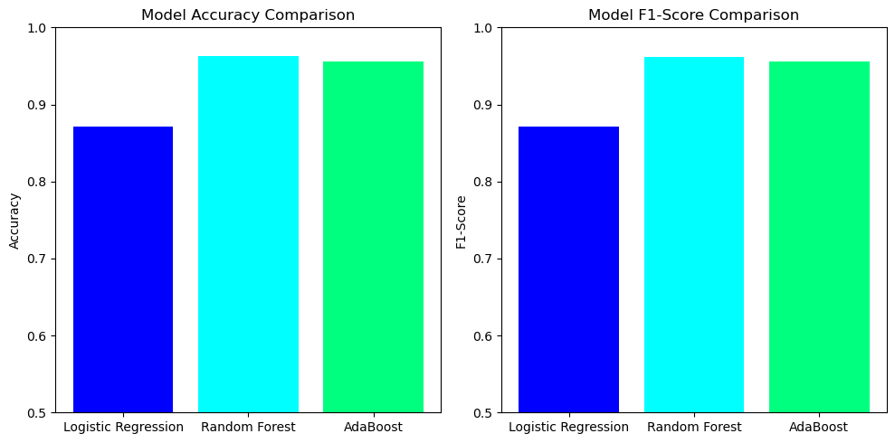

```python
# Plot comparison
plt.figure(figsize=(10, 5))

# Accuracy plot
plt.subplot(1, 2, 1)
plt.bar(results_df['Model'], results_df['Accuracy'], color=['blue', 'cyan', 'springgreen'])
plt.title('Model Accuracy Comparison')
plt.ylim(0.5, 1)
plt.ylabel('Accuracy')

# F1-Score plot
plt.subplot(1, 2, 2)
plt.bar(results_df['Model'], results_df['F1-Score'], color=['blue', 'cyan', 'springgreen'])
plt.title('Model F1-Score Comparison')
plt.ylim(0.5, 1)
plt.ylabel('F1-Score')

plt.tight_layout()
plt.show()
```

# Conclusions

Regarding hyperparamter tunning, these are the optimal values:

- **Logistic Regression**: {'C': 1, 'max_iter': 100, 'penalty': 'l2', 'solver': 'sag'}
- **Random Forest**: {'max_depth': 30, 'min_samples_leaf': 1, 'min_samples_split': 10, 'n_estimators': 100}
- **Adaboost**: {'algorithm': 'SAMME.R', 'estimator__max_depth': 3, 'learning_rate': 1.0, 'n_estimators': 100}

To sum up:

- Logistic Regression, while interpretable, underperformed (87.1% accuracy) due to its linearity assumption, making it unsuitable as a final solution.
- Random Forest is the top performer, achieving 96.2% accuracy and near-perfect F1-scores (0.96–0.97) for both satisfied and dissatisfied passengers. This model is ideal for deployment because it is the best at capturing complex feature interactions.
- AdaBoost is a strong alternative, with marginally lower accuracy (95.6%) but faster training. So, if there is a focus on speed and lightweight deployment, Adaboost will be a better option.